# PRÁCTICA 3 - FAA

### REGRESIÓN LOGÍSTICA Y ANÁLISIS ROC

#### 24 Noviembre 2022

Alejandro Coloma y S. Xiao Férnandez - Grupo 9

#### Resultados

```python
from MainPractica3FAA import *
test_propio()
```

| Cte Aprendizaje | # epoch | diabetes - Media | diabetes - D. Típica | wdbc - Media | wdbc - D. Típica |
| --- | --- | --- | --- | --- | --- |
| 0.25 | 500 | 0.34771242 | 0.04243839 | 0.11327434 | 0.05635994 |
|  | 1000 | 0.34117647 | 0.03951952 | 0.09911504 | 0.01415929 |
|  | 1500 | 0.64313725 | 0.01524432 | 0.08318584 | 0.02064054 |
| 0.5 | 500 | 0.36993464 | 0.12322298 | 0.11681416 | 0.06954649 |
|  | 1000 | 0.35032680 | 0.02760616 | 0.11150442 | 0.03292226 |
|  | 1500 | 0.52549020 | 0.10760322 | 0.07433628 | 0.01200412 |
| 0.75 | 500 | 0.34379085 | 0.02940450 | 0.08141593 | 0.02707444 |
|  | 1000 | 0.38692810 | 0.02424475 | 0.08672566 | 0.02400825 |
|  | 1500 | 0.51241830 | 0.06125686 | 0.07964602 | 0.02167690 |
| 1 | 500 | 0.41699346 | 0.01999615 | 0.09203540 | 0.02280371 |
|  | 1000 | 0.46928105 | 0.11760348 | 0.16460177 | 0.07604443 |
|  | 1500 | 0.35555556 | 0.05399183 | 0.09026549 | 0.02820775 |

#### Explicación del código y decisiones tomadas.

Para completar el entrenamineto, hemos saeguido el pdf de moodle, que es basicamente hacer el algoritmo de RL que hemos parendido en las clases de teoría.

Para las epocas, hemos usado [500, 1000, 1500], y para las constantes de aprendizaje [0.25, 0.5, 0.75, 1]. Todo esto calculando con validación cruzada, ya que como comentabamos en la anterior práctica, en la primera entrega de practicas, nos daba menor media.

#### Análisis de los resultados

**Probar con diferentes valores para la constante de aprendizaje y el número de pasos**

Podemos observar que wdbc da mucho mejor resultado que el dataset de diabetes. Esto se pude deber a que wdbc si que es una dataset linealmente separable y sigue una distribucion normal con matrices de covarianza iguales a la identidad y abas clases, no como prima-indians-diabetes.

### RL SKLearn

```python
from MainPractica3FAA import *
test_SKL()
```

| Cte Aprendizaje | # epoch | diabetes - Media | diabetes - D. Típica | wdbc - Media | wdbc - D. Típica |
| --- | --- | --- | --- | --- | --- |
| 0.25 | 500 | 0.42462440 | 0.12114539 | 0.15629561 | 0.08053241 |
|  | 1000 | 0.45827179 | 0.12034647 | 0.09487657 | 0.01001565 |
|  | 1500 | 0.47270181 | 0.14354367 | 0.15126533 | 0.05439877 |
| 0.5 | 500 | 0.39484764 | 0.10075439 | 0.13356622 | 0.03976714 |
|  | 1000 | 0.41921738 | 0.03931160 | 0.08428815 | 0.02443403 |
|  | 1500 | 0.36323742 | 0.02891896 | 0.11951560 | 0.04761330 |
| 0.75 | 500 | 0.39836177 | 0.11674162 | 0.07910262 | 0.02082599 |
|  | 1000 | 0.39432985 | 0.11050556 | 0.13524297 | 0.04005431 |
|  | 1500 | 0.39309057 | 0.10300036 | 0.13872070 | 0.11999920 |
| 1 | 500 | 0.40613700 | 0.07649545 | 0.13005744 | 0.04093159 |
|  | 1000 | 0.42333418 | 0.11289633 | 0.15283341 | 0.04004426 |
|  | 1500 | 0.42309651 | 0.12087157 | 0.13867412 | 0.11395718 |

#### Explicación del código y decisiones tomadas.

Para SGDClassifier, las variables usadas han sido:

max_iter: epocas, el numero de epocas que queremos que la regresion logisitica tenga.

eta0: cteaprend, la constante de aprendizajed del modelo.

learning_rate: optimal, donde eta = 1.0 / (alpha * (t + t0)).

### Comparar y analizar los resultados propios con los de Scikit-Learn

En los dos casos, la media de diabetes nos da super alta. Como hemos dicho, porque no es un dataset linearmente separable.

### Análisis ROC

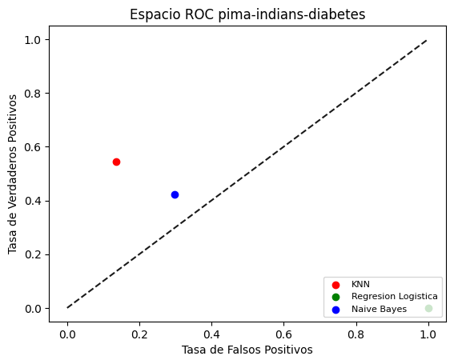

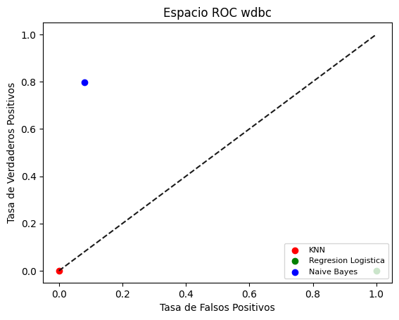

```python
from MainPractica3FAA import *
test_ROC()
```

TPR frente a FPR es lo que se denomina Espacio ROC. Para calcular esto, en primer lugar obtenemos la matriz de confusión para los conjuntos de datos pima-indian y wdbc. Hay una matriz por cada conjunto y clasificador. A partir del Espacio ROC ya se puede analizar el rendimiento de cada clasificador respecto al dataset considerado, teniendo en cuenta su posición respecto a la diagonal, que representa una clasificación completamente aleatoria.

**Comparar Naive Bayes, Vecinos Próximos y Regresión Logística**

Para pima-indian-diabetes, no da muy buenos resultados, ya que los 3 clasificadores se alejan mucho de (0, 1). La mejor sería KNN, pero tampoco podríamos decir que es muy exacto, ya que tu tasa de falsos positivos es muy baja pero si tasa de verdaderps posritivos es muy cercana a 50%. Naive bayes es la mas cercana a ser clasificada en un punto donde lo considera un clasificador que clasifica de forma aleatoria. La tasa de falsos positivos en RL es 100 y la tasa de verdaderos positivos es 0.

Para wdbc, la peor es regeresion logistica, donde la tasa de verdaderos positivos es 0, (al igual que KNN). La tasa de falsos positivos en RL es 100%, totalmente contraria a KNN, que da 0 (clasifica como positivo de forma errónea menos veces), al igual que su tasa de verdaderos positivos (clasifica como positivo correctamente muy pocas veces). Es tan bajo en KNN que lo clasifica en un punto donde lo considera un clasificador que clasifica de forma aleatoria. La mejor es NB, que estas cerca del punto (0, 1), que seria un clasificador perfecto.

### Dibuja la Curva ROC para RL

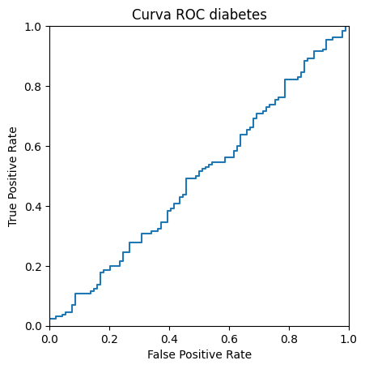

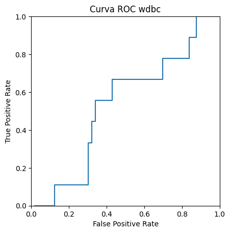

```python
from MainPractica3FAA import *
test_curva_ROC()
```

Para dibujar la curva ROC característica de un clasificador necesitamos conocer los umbrales de clasificación del modelo, conocer la confianza que tiene un clasificador en una clasificación

**Analiza el área bajo la curva (AUC) y discute los resultados.**

En pima indians, la curva roc se acerca mucho a un clasificador aleatorio y tiene sentido ya que en nuesto clasificador implementado, los resultados dan alrededor de 60-30% dependiendo de las epocas y la constante de aprendizaje. Sin embargo, para wdbc, se aleja mas de un clasificador aleatorio, aunque tampoco mucho. El area abjo la curva es mas grande que en pima indians, que representa que este clasificador es mejor para clasificar clases negativas y positivas.